# STAT 413/613 Homework on Web Data: APIs and Scraping

Ifebunandu Jerome Okeke

2021-03-16

# Instructions

- Write your solutions **in this starter file**.
  - Modify the “author” field in the YAML header.
- Commit R Markdown and HTML files (no PDF files). **Push both .Rmd and HTML files to GitHub**.
  - Make sure you have knitted to HTML for your final submission.
- **Only include necessary code and data** to answer the questions.
- Most of the functions you use should be from the tidyverse. **Too much base R** will result in point deductions.
- Submit a response on Canvas that your assignment is complete on GitHub
- Feel free to use Pull requests and or email (attach your .Rmd) to ask me any questions.

# 1 Using APIs

- Pick a website of your choice (not discussed in class) that requires a free API key to download a data set. Convert elements of interest into a tibble and create a graph to answer a question of interest.
- State the question and interpret the plot.

```r
# Load required Libraries
library(keyring)
library(tidyverse)
library(httr)
library(jsonlite)
library(usethis)
```

## 1.1

## 1.2 Data From The Movie Database(TMDB)

```r
movie_recomm <- GET(url = "https://api.themoviedb.org/3/movie/343611/recommendations?api_key=ec8181d2db5dadf144351e531527d2ac&language=en-US&page=1")

status_code(movie_recomm)
```

```
## [1] 200
```

## 1.3

## 1.4

```r
is.raw(movie_recomm$content)
```

```
## [1] TRUE
```

```r
movie_recomm$content
```

[output not shown]

[output cut: 471 more lines]

## 1.5

## 1.6

Tidy and Clean Data.

```r
glimpse(content(movie_recomm, as = "text"))
```

```
##  chr "{\"page\":1,\"results\":[{\"adult\":false,\"backdrop_path\":\"/k7h4RNAarfOrF2r2YMN0P2FQSr4.jpg\",\"genre_ids\":"| __truncated__
```

```r
top_movie <- content(movie_recomm, as = "text")

movie_selct <- fromJSON(top_movie, flatten = TRUE)
```

## 1.7

```r
best_movie <- movie_selct$results
```

## 1.8

# 2 Question of Interest.

A. The question of interest is identify the movie with the highest vote count. The ggplot will be utilized for this analysis.

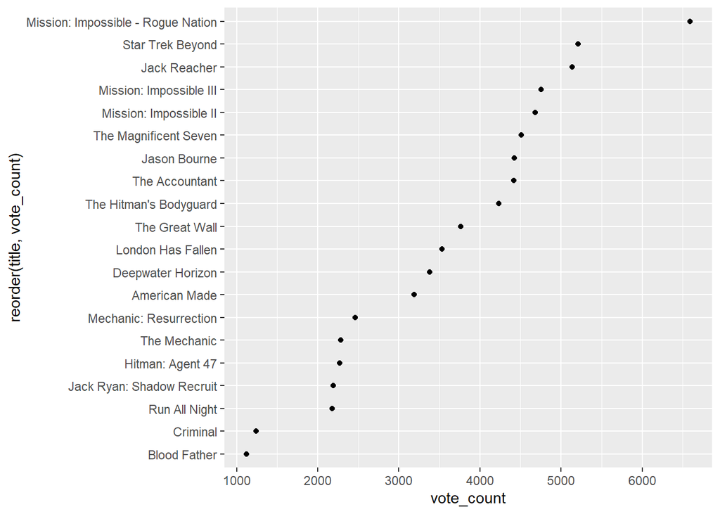

```r
best_movie %>%
  ggplot(aes(x = vote_count, y = reorder(title, vote_count))) +
  geom_point()
```

**-** Our graph shows mission Impossible-rogue nation as the movie with the highest vote count.

## 2.1

B. We can explore further analysis by creating a plot to ascertain the relationship between vote_count and popularity. A linear model will be used to assess if there is there a meaningful relationship

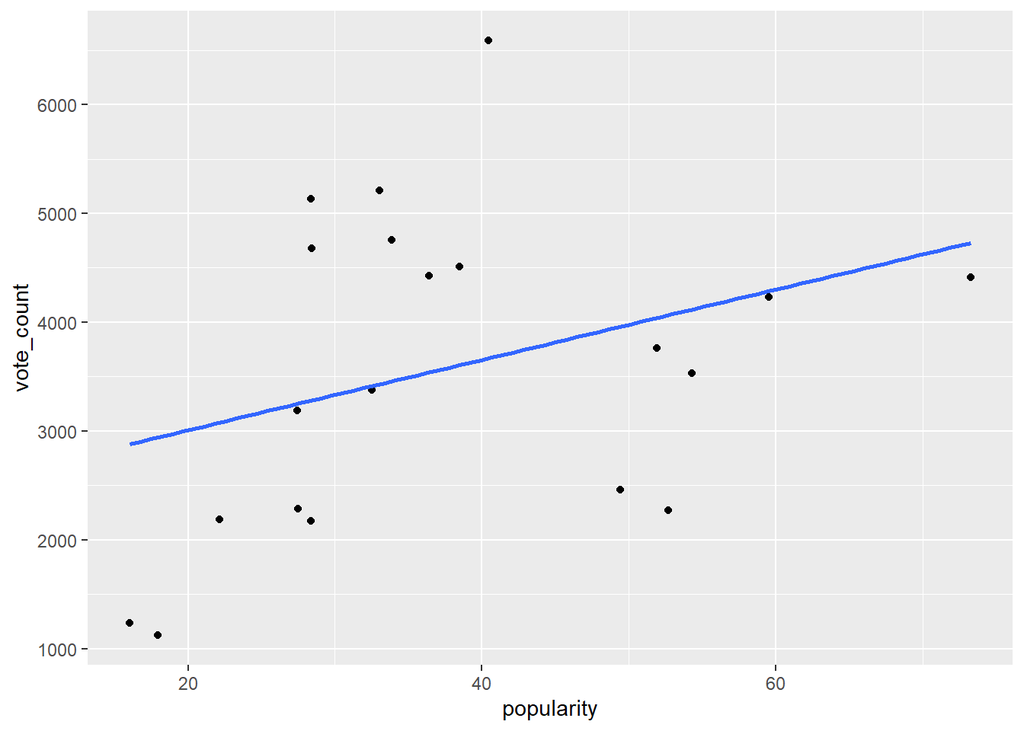

```r
best_movie %>%

  ggplot(aes(x = popularity, y = vote_count)) +

  geom_point() +

  geom_smooth(method = "lm", se = FALSE)
```

- Below is the summary output analysis

```r
best_movie_lm <- lm(vote_count ~ popularity, data = best_movie)

summary(best_movie_lm)
```

```
##
## Call:
## lm(formula = vote_count ~ popularity, data = best_movie)
##
## Residuals:
##     Min      1Q  Median      3Q     Max
## -1822.3 -1003.1  -170.3  1006.1  2918.2
##
## Coefficients:
##             Estimate Std. Error t value Pr(>|t|)
## (Intercept)  2362.45     869.39   2.717   0.0141 *
## popularity     32.31      21.57   1.498   0.1514
## ---
## Signif. codes:  0 '***' 0.001 '**' 0.01 '*' 0.05 '.' 0.1 ' ' 1
##
## Residual standard error: 1402 on 18 degrees of freedom
## Multiple R-squared:  0.1109, Adjusted R-squared:  0.06147
## F-statistic: 2.244 on 1 and 18 DF,  p-value: 0.1514
```

# 3 Excercise 2

# 4 IMDB List of Oscar Winners

IMDB has a list of the [Oscar Best Picture Winners](https://www.imdb.com/search/title/?count=100&groups=oscar_best_picture_winners&sort=year%2Cdesc&ref_=nv_ch_osc).

Scrape the following elements, convert the data into a tibble, tidy it, and clean it to answer the questions below:

- Number
- Title
- Year
- MPAA Rating
- Length in minutes
- Genre
- Star Rating
- Metascore Rating
- Gross Receipts

Convert the data into a tibble, tidy it, and clean it to answer the following questions:

## 4.1 Solutions:

```r
# Scrap the data

library(rvest)
IMDB_HTML <- read_html("https://www.imdb.com/search/title/?count=100&groups=oscar_best_picture_winners&sort=year%2Cdesc&ref_=nv_ch_osc")
```

## 4.2

## 4.3

```r
IMDBDATA <- html_nodes(IMDB_HTML, css = ".ghost~ .text-muted+ span , .favorable , .ratings-imdb-rating strong , .genre , .runtime , .certificate , .unbold , .lister-item-header a")

IMDBHTMLTEXT <- html_text(IMDBDATA)

length(IMDBHTMLTEXT)
```

```
## [1] 810
```

## 4.4

```r
OSCAR_BESTPIC <- tibble(text = IMDBHTMLTEXT)

OSCAR_BESTPIC
```

```
## # A tibble: 810 x 1
##    text
##    <chr>
##  1 "1."
##  2 "Parasite"
##  3 "(2019)"
##  4 "R"
##  5 "132 min"
##  6 "\nComedy, Drama, Thriller            "
##  7 "8.6"
##  8 "96        "
##  9 "$53.37M"
## 10 "2."
## # ... with 800 more rows
```

## 4.5

```r
## get movie numbers and remove non-movie elements:
OSCAR_BESTPIC %>%
  mutate(MOVIENUM = str_detect(text,"^\\d+\\.$")) -> OSCAR_BESTPIC
sum(OSCAR_BESTPIC$MOVIENUM)
```

```
## [1] 93
```

## 4.6

```r
OSCAR_BESTPIC %>%

  mutate(POSITION = cumsum(MOVIENUM)) %>%

  filter(POSITION > 0) ->

  OSCAR_BESTPIC
```

## 4.7

## 4.8

Tidy and clean Data

```r
MOVIE_ELEMENTS <- (html_nodes(IMDB_HTML,
                               css = ".lister-item-header a , .text-primary"))

RANKING_TEXT <- html_text(MOVIE_ELEMENTS)

RANKING_TEXT %>%

  tibble(text = RANKING_TEXT) %>%

  mutate(rownum = row_number(),

         iseven = rownum %% 2 == 0,

         movie = rep(1:93, each = 2)) %>%

select(-rownum) %>%

pivot_wider(names_from = iseven, values_from = text) %>%

select(-movie, "Rank" = "FALSE", movie = "TRUE") %>%

  mutate(Rank = parse_number(Rank)) ->

  MOVIERANK
```

## 4.9

## 4.10

```r
OSCAR_BESTPIC %>%
  mutate(TITLE = text %in% MOVIERANK$movie) ->
  OSCAR_BESTPIC
```

## 4.11

## 4.12

```r
OSCAR_BESTPIC %>%
  mutate(YEAR = str_detect(text, "\\(\\d{4}\\)")) -> OSCAR_BESTPIC

OSCAR_BESTPIC %>%
  count(YEAR)
```

```
## # A tibble: 2 x 2
##   YEAR      n
##   <lgl> <int>
## 1 FALSE   717
## 2 TRUE     93
```

## 4.13

```r
RATING <- c("G", "PG", "PG-13", "R", "NC-17", "GP", "Not Rated", "Passed", "Approved")

OSCAR_BESTPIC %>%
  mutate(MPA_RATING = text %in% RATING) -> OSCAR_BESTPIC

OSCAR_BESTPIC %>%
  count(MPA_RATING)
```

```
## # A tibble: 2 x 2
##   MPA_RATING     n
##   <lgl>      <int>
## 1 FALSE        717
## 2 TRUE          93
```

## 4.14

## 4.15

```r
OSCAR_BESTPIC %>%
  mutate(LGTH_IN_MINS = str_detect(text, "(^\\d+)\\s(min$)")) -> OSCAR_BESTPIC

OSCAR_BESTPIC %>%
  count(LGTH_IN_MINS)
```

```
## # A tibble: 2 x 2
##   LGTH_IN_MINS     n
##   <lgl>        <int>
## 1 FALSE          717
## 2 TRUE            93
```

## 4.16

## 4.17

```r
OSCAR_BESTPIC %>%
  mutate(GENRE = str_detect(text, "^\\n")) -> OSCAR_BESTPIC

OSCAR_BESTPIC %>%
  count(GENRE)
```

```
## # A tibble: 2 x 2
##   GENRE     n
##   <lgl> <int>
## 1 FALSE   717
## 2 TRUE     93
```

## 4.18

```r
OSCAR_BESTPIC %>%
  mutate(STAR_RATING = str_detect(text, "(^\\d{1})\\.(\\d{1}$)")) -> OSCAR_BESTPIC

OSCAR_BESTPIC %>%
  count(STAR_RATING)
```

```
## # A tibble: 2 x 2
##   STAR_RATING     n
##   <lgl>       <int>
## 1 FALSE         717
## 2 TRUE           93
```

## 4.19

## 4.20

```r
OSCAR_BESTPIC %>%
  mutate(METASCORE_RATING = str_detect(text, "(^\\d+\\s+$)")) -> OSCAR_BESTPIC

OSCAR_BESTPIC %>%
  count(METASCORE_RATING)
```

```
## # A tibble: 2 x 2
##   METASCORE_RATING     n
##   <lgl>            <int>
## 1 FALSE              734
## 2 TRUE                76
```

## 4.21

```r
OSCAR_BESTPIC %>%
  mutate(GROSS_RECEIPTS = str_detect(text, "(^\\$\\d+)\\.(\\d+)M$")) -> OSCAR_BESTPIC

OSCAR_BESTPIC %>%
  count(GROSS_RECEIPTS)
```

```
## # A tibble: 2 x 2
##   GROSS_RECEIPTS     n
##   <lgl>          <int>
## 1 FALSE            727
## 2 TRUE              83
```

## 4.22

```r
OSCAR_BESTPIC %>%
  mutate(ELEMENTS = case_when(MOVIENUM ~ "Number",
                         TITLE ~ "Title",
                         YEAR ~ "Year",
                         MPA_RATING ~ "MPAARating",
                         LGTH_IN_MINS ~ "LengthinMinutes",
                         GENRE ~ "Genre",
                         STAR_RATING ~ "StarRating",
                         METASCORE_RATING ~ "MetascoreRating",
                         GROSS_RECEIPTS ~ "GrossReceipts")) %>%
  select(ELEMENTS, text, POSITION) %>%
  pivot_wider(names_from = ELEMENTS, values_from = text) -> NEW_OSCAR_BESTPIC

 NEW_OSCAR_BESTPIC
```

```
## # A tibble: 93 x 10
##    POSITION Number Title Year  MPAARating LengthinMinutes Genre StarRating
##       <int> <chr>  <chr> <chr> <chr>      <chr>           <chr> <chr>
##  1        1 1.     Para~ (201~ R          132 min         "\nC~ 8.6
##  2        2 2.     Gree~ (201~ PG-13      130 min         "\nB~ 8.2
##  3        3 3.     The ~ (201~ R          123 min         "\nA~ 7.3
##  4        4 4.     Moon~ (I) ~ R          111 min         "\nD~ 7.4
##  5        5 5.     Spot~ (I) ~ R          129 min         "\nB~ 8.1
##  6        6 6.     Bird~ (201~ R          119 min         "\nC~ 7.7
##  7        7 7.     12 Y~ (201~ R          134 min         "\nB~ 8.1
##  8        8 8.     Argo  (201~ R          120 min         "\nB~ 7.7
##  9        9 9.     The ~ (I) ~ PG-13      100 min         "\nC~ 7.9
## 10       10 10.    The ~ (201~ R          118 min         "\nB~ 8.0
## # ... with 83 more rows, and 2 more variables: MetascoreRating <chr>,
## #   GrossReceipts <chr>
```

## 4.23

```r
# Clean the Data

NEW_OSCAR_BESTPIC %>%

  mutate(Number = parse_number(Number),

         Year = parse_number(Year),

         `MPAARating` = parse_factor(`MPAARating`),

         `LengthinMinutes` = str_replace_all(`LengthinMinutes`, "(\\s)min", ""),

         `LengthinMinutes` = parse_number(`LengthinMinutes`),

         Genre = str_replace_all(Genre, "\\n", ""),

         Genre = str_squish(Genre),

         `StarRating` = parse_number(`StarRating`),

         `MetascoreRating` = parse_number(`MetascoreRating`),

         `GrossReceipts` = str_replace_all(`GrossReceipts`, "\\$", ""),

         `GrossReceipts` = str_replace_all(`GrossReceipts`, "(M$)", ""),

         `GrossReceipts` = parse_number(`GrossReceipts`),

         POSITION = NULL) ->    NEW_OSCAR_BESTPIC

NEW_OSCAR_BESTPIC
```

```
## # A tibble: 93 x 9
##    Number Title  Year MPAARating LengthinMinutes Genre StarRating
##     <dbl> <chr> <dbl> <fct>                <dbl> <chr>      <dbl>
##  1      1 Para~  2019 R                      132 Come~        8.6
##  2      2 Gree~  2018 PG-13                  130 Biog~        8.2
##  3      3 The ~  2017 R                      123 Adve~        7.3
##  4      4 Moon~  2016 R                      111 Drama        7.4
##  5      5 Spot~  2015 R                      129 Biog~        8.1
##  6      6 Bird~  2014 R                      119 Come~        7.7
##  7      7 12 Y~  2013 R                      134 Biog~        8.1
##  8      8 Argo   2012 R                      120 Biog~        7.7
##  9      9 The ~  2011 PG-13                  100 Come~        7.9
## 10     10 The ~  2010 R                      118 Biog~        8
## # ... with 83 more rows, and 2 more variables: MetascoreRating <dbl>,
## #   GrossReceipts <dbl>
```

## 4.24

## 4.25

```r
Data_elements <- c("METASCORE_RATING", "MOVIENUM", "TITLE",
           "YEAR", "MPA_RATING", "LGTH_IN_MINS",
           "GENRE", "STAR_RATING", "GROSS_RECEIPTS")

OSCAR_BESTPIC %>%

  group_by(METASCORE_RATING, MOVIENUM, TITLE,YEAR, MPA_RATING, LGTH_IN_MINS,
           GENRE, STAR_RATING, GROSS_RECEIPTS) %>%

  count() -> Element_summary


tibble(Data_elements, count =  Element_summary$n)
```

[output not shown]

## 4.26

2. Create a plot of the length of a film and its gross, color coded by rating. Show linear smoother for each rating.
- Does MPAA rating matter?

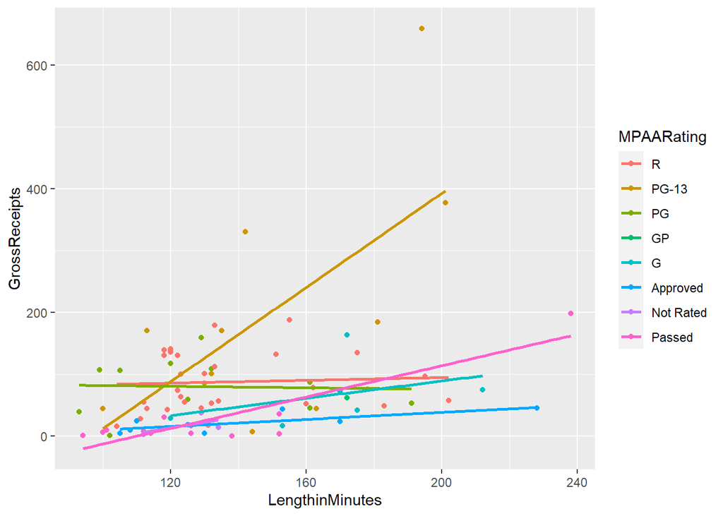

```r
NEW_OSCAR_BESTPIC %>%
  filter(!is.na(GrossReceipts)) %>%
  ggplot(aes(x = LengthinMinutes, y = GrossReceipts, color = MPAARating)) +
  geom_point() +
  geom_smooth(method = "lm", se = FALSE)
```

**-** MPAA Rating does matter. The plot above shows that PG-13 has the most rating but also has the most Gross Receipts.

## 4.27

3. Create a plot with a single Ordinary Least Squares smoothing line with no standard errors showing for predicting stars rating based on metacritic scores for those movies that have metacritic scores.
- Use a linear model to assess if there is there a meaningful relationship. Show the summary of the output and interpret in terms of the $p$-value and the adjusted R-Squared?

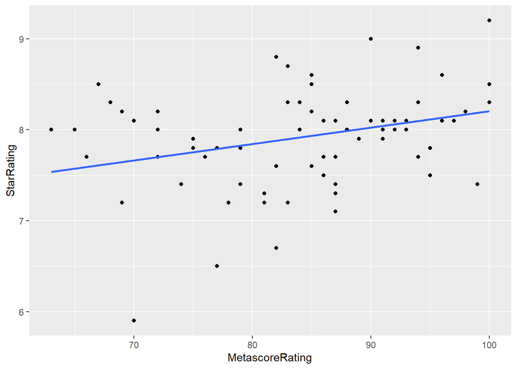

```r
NEW_OSCAR_BESTPIC %>%

  filter(!is.na(MetascoreRating)) %>%

  ggplot(aes(x = MetascoreRating, y = StarRating)) +

  geom_point() +

  geom_smooth(method = lm, se = FALSE)
```

**-** The plot shows that there is a positive relationship between Star Rating and Metascore Rating.

## 4.28

- Summary output

```r
OSCAR_BESTPIC_LM <- lm(StarRating ~ MetascoreRating, data = NEW_OSCAR_BESTPIC)

summary(OSCAR_BESTPIC_LM)
```

```
##
## Call:
## lm(formula = StarRating ~ MetascoreRating, data = NEW_OSCAR_BESTPIC)
##
## Residuals:
##     Min      1Q  Median      3Q     Max
## -1.7609 -0.2868  0.0369  0.3055  0.9965
##
## Coefficients:
##                 Estimate Std. Error t value Pr(>|t|)
## (Intercept)     6.394875   0.557866  11.463  < 2e-16 ***
## MetascoreRating 0.018087   0.006572   2.752  0.00744 **
## ---
## Signif. codes:  0 '***' 0.001 '**' 0.01 '*' 0.05 '.' 0.1 ' ' 1
##
## Residual standard error: 0.5297 on 74 degrees of freedom
##   (17 observations deleted due to missingness)
## Multiple R-squared:  0.09285,    Adjusted R-squared:  0.08059
## F-statistic: 7.574 on 1 and 74 DF,  p-value: 0.007443
```

## 4.29

4. Use an appropriate plot to compare the gross receipts by MPAA rating.
- Which MPAA rating has the highest median gross receipts?
- Which R-rated movies are in the overall top 10 of gross receipts?
- Use one-way analysis of variance to assess the level of evidence for whether all ratings have the same mean gross receipts. Show the summary of the results and provide your interpretation of the results.

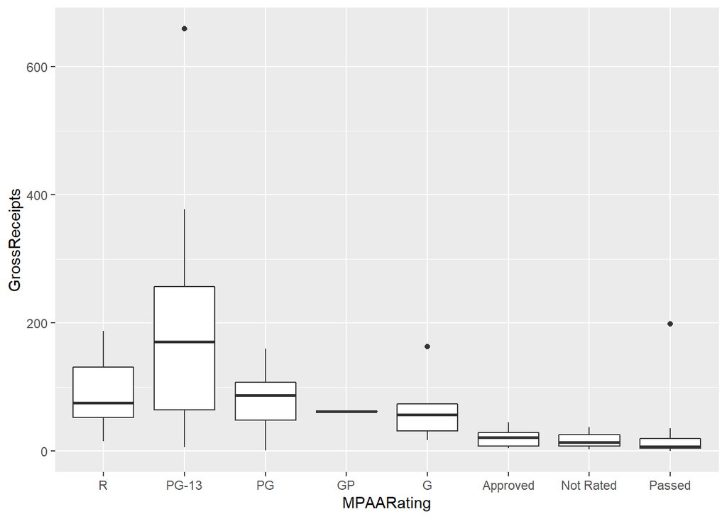

```r
NEW_OSCAR_BESTPIC %>%

  filter(!is.na(GrossReceipts)) %>%

  ggplot(aes(x = MPAARating, y = GrossReceipts)) +

  geom_boxplot()
```

**-** The MPAA rating with the highest median gross receipts is the PG-13

## 4.30

- Which R-rated movies are in the overall top 10 of gross receipts?

```r
NEW_OSCAR_BESTPIC %>%

  arrange(-GrossReceipts)
```

```
## # A tibble: 93 x 9
##    Number Title  Year MPAARating LengthinMinutes Genre StarRating
##     <dbl> <chr> <dbl> <fct>                <dbl> <chr>      <dbl>
##  1     23 Tita~  1997 PG-13                  194 Dram~        7.8
##  2     17 The ~  2003 PG-13                  201 Acti~        8.9
##  3     26 Forr~  1994 PG-13                  142 Dram~        8.8
##  4     81 Gone~  1939 Passed                 238 Dram~        8.1
##  5     20 Glad~  2000 R                      155 Acti~        8.5
##  6     30 Danc~  1990 PG-13                  181 Adve~        8
##  7     32 Rain~  1988 R                      133 Drama        8
##  8     19 A Be~  2001 PG-13                  135 Biog~        8.2
##  9     18 Chic~  2002 PG-13                  113 Come~        7.2
## 10     55 The ~  1965 G                      172 Biog~        8
## # ... with 83 more rows, and 2 more variables: MetascoreRating <dbl>,
## #   GrossReceipts <dbl>
```

**-** Gladiator and Rain Man

## 4.31

## 4.32

```r
summary(aov(StarRating ~ GrossReceipts, data = NEW_OSCAR_BESTPIC))
```

```
##               Df Sum Sq Mean Sq F value  Pr(>F)
## GrossReceipts  1  2.474  2.4739   7.095 0.00933 **
## Residuals     81 28.245  0.3487
## ---
## Signif. codes:  0 '***' 0.001 '**' 0.01 '*' 0.05 '.' 0.1 ' ' 1
## 10 observations deleted due to missingness
```

# 5 Extra Credit 1 Pts

- Listen to the AI Today podcast on [Machine Learning Ops](https://podcasts.apple.com/us/podcast/ai-today-podcast-artificial-intelligence-insights-experts/id1279927057?i=1000468771571) and provide your thoughts on the following questions:
1. Does knowing about Git and GitHub help you in understanding the podcast?

# 6 Ans.

Yes, it does help me understand the podcast especially when the guest talked about keeping tracks of things and managing and monitoring models.

2. How do you think the ideas of ML OPs will affect your future data science projects?

#Ans

Things are really moving fast with AI and I think that the idea of MLops with definitely have a huge impact in the way data science is seen and practiced in the future. There are so many unresolved issues that requires solution and this will bring about the change in the way data science in practiced and what their job requirement will entail.

You may also want to check out this article on [Towards Data Science](https://towardsdatascience.com/ml-ops-machine-learning-as-an-engineering-discipline-b86ca4874a3f)